# 2021 rides

Antonio

2022-07-05

## Setting up my environment

Notes: Setting up my R environment by loading the ‘tidyverse’,  
‘dplyr’, ‘readxl’, and ‘lubdridate’ packages.

```r
library(tidyverse)
library(dplyr)
library(readxl)
library(lubridate)
```

## Import Our Data

Notes: Here we would be transferring our data from excel into R, the data can be found [ride data](https://divvy-tripdata.s3.amazonaws.com/index.html). What was added into the raw excel data is the difference from end_dration and start_duration and the different days using WEEKDAY function.

```r
m1_y2021 <- read_excel("~/Downloads/202101-divvy-tripdata(AutoRecovered).xls")
m2_y2021 <- read_excel("~/Downloads/202102-divvy-tripdata.xls")
m3_y2021 <- read_excel("~/Downloads/202103-divvy-tripdata.xls")
m4_y2021 <- read_excel("~/Downloads/202104-divvy-tripdata.xls")
m5_y2021 <- read_excel("~/Downloads/202105-divvy-tripdata.xls")
m6_y2021 <- read_excel("~/Downloads/202106-divvy-tripdata.xls")
m7_y2021 <- read_excel("~/Downloads/202107-divvy-tripdata.xls")
m8_y2021 <- read_excel("~/Downloads/202108-divvy-tripdata.xls")
m9_y2021 <- read_excel("~/Downloads/202109-divvy-tripdata.xls")
m10_y2021 <- read_excel("~/Downloads/202110-divvy-tripdata.xls")
m11_y2021 <- read_excel("~/Downloads/202111-divvy-tripdata.xls")
m12_y2021 <- read_excel("~/Downloads/202112-divvy-tripdata.xls")
```

## Inspect Data

Notes: Here we would be searching for incongruencies

```r
str(m1_y2021)
```

```
## tibble [65,535 × 21] (S3: tbl_df/tbl/data.frame)
##  $ ride_id           : chr [1:65535] "000DA68A9DC52C89" "6792586601957840" "002BD6D2A609C1C3" "899295120026675" ...
##  $ rideable_type     : chr [1:65535] "classic_bike" "electric_bike" "classic_bike" "electric_bike" ...
##  $ started_at        : POSIXct[1:65535], format: "2021-01-17 06:22:09" "2021-01-10 13:57:06" ...
##  $ ended_at          : POSIXct[1:65535], format: "2021-01-17 06:26:21" "2021-01-10 14:06:36" ...
##  $ start_station_name: chr [1:65535] "Rhodes Ave & 32nd St" NA "Wabash Ave & Roosevelt Rd" "Wells St & Concord Ln" ...
##  $ start_station_id  : chr [1:65535] "13215" NA "TA1305000002" "TA1308000050" ...
##  $ end_station_name  : chr [1:65535] "Indiana Ave & 31st St" NA "Clinton St & Roosevelt Rd" NA ...
##  $ end_station_id    : chr [1:65535] "TA1308000036" NA "WL-008" NA ...
##  $ start_lat         : num [1:65535] 41.8 42 41.9 41.9 41.7 ...
##  $ start_lng         : num [1:65535] -87.6 -87.7 -87.6 -87.6 -87.5 ...
##  $ end_lat           : num [1:65535] 41.8 42 41.9 41.9 41.8 ...
##  $ end_lng           : num [1:65535] -87.6 -87.7 -87.6 -87.6 -87.5 ...
##  $ member_casual     : chr [1:65535] "casual" "member" "casual" "member" ...
##  $ ride_length       : num [1:65535] 4.2 9.5 7.35 1.58 19.4 ...
##  $ day_of_week       : num [1:65535] 1 1 1 1 1 1 1 1 1 1 ...
##  $ sum_casu_class_sun: num [1:65535] 1355 NA NA NA NA ...
##  $ sum_casu_elec_sun : num [1:65535] 1157 NA NA NA NA ...
##  $ average           : num [1:65535] 15.3 NA NA NA NA ...
##  $ ...19             : logi [1:65535] NA NA NA NA NA NA ...
##  $ ...20             : logi [1:65535] NA NA NA NA NA NA ...
##  $ ...21             : logi [1:65535] NA NA NA NA NA NA ...
```

```r
str(m2_y2021)
```

```
## tibble [49,622 × 18] (S3: tbl_df/tbl/data.frame)
##  $ ride_id           : chr [1:49622] "89E7AA6C29227EFF" "0FEFDE2603568365" "E6159D746B2DBB91" "B32D3199F1C2E75B" ...
##  $ rideable_type     : chr [1:49622] "classic_bike" "classic_bike" "electric_bike" "classic_bike" ...
##  $ started_at        : POSIXct[1:49622], format: "2021-02-12 16:14:56" "2021-02-14 17:52:38" ...
##  $ ended_at          : POSIXct[1:49622], format: "2021-02-12 16:21:43" "2021-02-14 18:12:09" ...
##  $ start_station_name: chr [1:49622] "Glenwood Ave & Touhy Ave" "Glenwood Ave & Touhy Ave" "Clark St & Lake St" "Wood St & Chicago Ave" ...
##  $ start_station_id  : chr [1:49622] "525" "525" "KA1503000012" "637" ...
##  $ end_station_name  : chr [1:49622] "Sheridan Rd & Columbia Ave" "Bosworth Ave & Howard St" "State St & Randolph St" "Honore St & Division St" ...
##  $ end_station_id    : chr [1:49622] "660" "16806" "TA1305000029" "TA1305000034" ...
##  $ start_lat         : num [1:49622] 42 42 41.9 41.9 41.8 ...
##  $ start_lng         : num [1:49622] -87.7 -87.7 -87.6 -87.7 -87.6 ...
##  $ end_lat           : num [1:49622] 42 42 41.9 41.9 41.8 ...
##  $ end_lng           : num [1:49622] -87.7 -87.7 -87.6 -87.7 -87.6 ...
##  $ member_casual     : chr [1:49622] "member" "casual" "member" "member" ...
##  $ ride_length       : num [1:49622] 6.78 19.52 8.87 4.42 15.23 ...
##  $ day_of_week       : num [1:49622] 6 1 3 3 3 4 2 5 7 7 ...
##  $ mean_of_ridelength: num [1:49622] 24.4 NA NA NA NA ...
##  $ max_ridelength    : num [1:49622] 30129 NA NA NA NA ...
##  $ most_times_used   : num [1:49622] 7 NA NA NA NA NA NA NA NA NA ...
```

```r
str(m3_y2021)
```

```
## tibble [65,535 × 15] (S3: tbl_df/tbl/data.frame)
##  $ ride_id           : chr [1:65535] "CFA86D4455AA1030" "30D9DC61227D1AF3" "846D87A15682A284" "994D05AA75A168F2" ...
##  $ rideable_type     : chr [1:65535] "classic_bike" "classic_bike" "classic_bike" "classic_bike" ...
##  $ started_at        : POSIXct[1:65535], format: "2021-03-16 08:32:30" "2021-03-28 01:26:28" ...
##  $ ended_at          : POSIXct[1:65535], format: "2021-03-16 08:36:34" "2021-03-28 01:36:55" ...
##  $ start_station_name: chr [1:65535] "Humboldt Blvd & Armitage Ave" "Humboldt Blvd & Armitage Ave" "Shields Ave & 28th Pl" "Winthrop Ave & Lawrence Ave" ...
##  $ start_station_id  : chr [1:65535] "15651" "15651" "15443" "TA1308000021" ...
##  $ end_station_name  : chr [1:65535] "Stave St & Armitage Ave" "Central Park Ave & Bloomingdale Ave" "Halsted St & 35th St" "Broadway & Sheridan Rd" ...
##  $ end_station_id    : chr [1:65535] "13266" "18017" "TA1308000043" "13323" ...
##  $ start_lat         : num [1:65535] 41.9 41.9 41.8 42 42 ...
##  $ start_lng         : num [1:65535] -87.7 -87.7 -87.6 -87.7 -87.7 ...
##  $ end_lat           : num [1:65535] 41.9 41.9 41.8 42 42.1 ...
##  $ end_lng           : num [1:65535] -87.7 -87.7 -87.6 -87.6 -87.7 ...
##  $ member_casual     : chr [1:65535] "casual" "casual" "casual" "casual" ...
##  $ ride_length       : num [1:65535] 4.07 10.45 16.4 28.98 17.93 ...
##  $ day_of_week       : num [1:65535] 3 1 5 5 1 7 7 3 4 5 ...
```

```r
str(m4_y2021)
```

```
## tibble [65,535 × 15] (S3: tbl_df/tbl/data.frame)
##  $ ride_id           : chr [1:65535] "6C992BD37A98A63F" "1E0145613A209000" "E498E15508A80BAD" "1887262AD101C604" ...
##  $ rideable_type     : chr [1:65535] "classic_bike" "docked_bike" "docked_bike" "classic_bike" ...
##  $ started_at        : POSIXct[1:65535], format: "2021-04-12 18:25:36" "2021-04-27 17:27:11" ...
##  $ ended_at          : POSIXct[1:65535], format: "2021-04-12 18:56:55" "2021-04-27 18:31:29" ...
##  $ start_station_name: chr [1:65535] "State St & Pearson St" "Dorchester Ave & 49th St" "Loomis Blvd & 84th St" "Honore St & Division St" ...
##  $ start_station_id  : chr [1:65535] "TA1307000061" "KA1503000069" "20121" "TA1305000034" ...
##  $ end_station_name  : chr [1:65535] "Southport Ave & Waveland Ave" "Dorchester Ave & 49th St" "Loomis Blvd & 84th St" "Southport Ave & Waveland Ave" ...
##  $ end_station_id    : chr [1:65535] "13235" "KA1503000069" "20121" "13235" ...
##  $ start_lat         : num [1:65535] 41.9 41.8 41.7 41.9 41.7 ...
##  $ start_lng         : num [1:65535] -87.6 -87.6 -87.7 -87.7 -87.7 ...
##  $ end_lat           : num [1:65535] 41.9 41.8 41.7 41.9 41.7 ...
##  $ end_lng           : num [1:65535] -87.7 -87.6 -87.7 -87.7 -87.7 ...
##  $ member_casual     : chr [1:65535] "member" "casual" "casual" "member" ...
##  $ ride_length       : num [1:65535] 31.3 64.3 5697.6 25.1 91.3 ...
##  $ day_of_week       : num [1:65535] 2 3 7 7 7 1 7 3 2 7 ...
```

```r
str(m5_y2021)
```

```
## tibble [65,535 × 15] (S3: tbl_df/tbl/data.frame)
##  $ ride_id           : chr [1:65535] "C809ED75D6160B2A" "DD59FDCE0ACACAF3" "0AB83CB88C43EFC2" "7881AC6D39110C60" ...
##  $ rideable_type     : chr [1:65535] "electric_bike" "electric_bike" "electric_bike" "electric_bike" ...
##  $ started_at        : POSIXct[1:65535], format: "2021-05-30 11:58:15" "2021-05-30 11:29:14" ...
##  $ ended_at          : POSIXct[1:65535], format: "2021-05-30 12:10:39" "2021-05-30 12:14:09" ...
##  $ start_station_name: chr [1:65535] NA NA NA NA ...
##  $ start_station_id  : chr [1:65535] NA NA NA NA ...
##  $ end_station_name  : chr [1:65535] NA NA NA NA ...
##  $ end_station_id    : chr [1:65535] NA NA NA NA ...
##  $ start_lat         : num [1:65535] 41.9 41.9 41.9 41.9 41.9 ...
##  $ start_lng         : num [1:65535] -87.6 -87.6 -87.7 -87.7 -87.7 ...
##  $ end_lat           : num [1:65535] 41.9 41.8 41.9 41.9 41.9 ...
##  $ end_lng           : num [1:65535] -87.6 -87.6 -87.7 -87.7 -87.7 ...
##  $ member_casual     : chr [1:65535] "casual" "casual" "casual" "casual" ...
##  $ ride_length       : num [1:65535] 12.4 44.92 1.2 15.22 6.88 ...
##  $ day_of_week       : num [1:65535] 1 1 1 1 1 1 1 4 4 3 ...
```

```r
str(m6_y2021)
```

```
## tibble [65,535 × 15] (S3: tbl_df/tbl/data.frame)
##  $ ride_id           : chr [1:65535] "99FEC93BA843FB20" "06048DCFC8520CAF" "9598066F68045DF2" "B03C0FE48C412214" ...
##  $ rideable_type     : chr [1:65535] "electric_bike" "electric_bike" "electric_bike" "electric_bike" ...
##  $ started_at        : POSIXct[1:65535], format: "2021-06-13 14:31:28" "2021-06-04 11:18:02" ...
##  $ ended_at          : POSIXct[1:65535], format: "2021-06-13 14:34:11" "2021-06-04 11:24:19" ...
##  $ start_station_name: chr [1:65535] NA NA NA NA ...
##  $ start_station_id  : chr [1:65535] NA NA NA NA ...
##  $ end_station_name  : chr [1:65535] NA NA NA NA ...
##  $ end_station_id    : chr [1:65535] NA NA NA NA ...
##  $ start_lat         : num [1:65535] 41.8 41.8 41.8 41.8 41.8 ...
##  $ start_lng         : num [1:65535] -87.6 -87.6 -87.6 -87.6 -87.6 ...
##  $ end_lat           : num [1:65535] 41.8 41.8 41.8 41.8 41.8 ...
##  $ end_lng           : num [1:65535] -87.6 -87.6 -87.6 -87.6 -87.6 ...
##  $ member_casual     : chr [1:65535] "member" "member" "member" "member" ...
##  $ ride_length       : num [1:65535] 2.72 6.28 5.98 25.83 4.13 ...
##  $ day_of_week       : num [1:65535] 1 6 6 5 6 5 5 5 5 4 ...
```

```r
str(m7_y2021)
```

```
## tibble [65,535 × 15] (S3: tbl_df/tbl/data.frame)
##  $ ride_id           : chr [1:65535] "0A1B623926EF4E16" "B2D5583A5A5E76EE" "6F264597DDBF427A" "379B58EAB20E8AA5" ...
##  $ rideable_type     : chr [1:65535] "docked_bike" "classic_bike" "classic_bike" "classic_bike" ...
##  $ started_at        : POSIXct[1:65535], format: "2021-07-02 14:44:36" "2021-07-07 16:57:42" ...
##  $ ended_at          : POSIXct[1:65535], format: "2021-07-02 15:19:58" "2021-07-07 17:16:09" ...
##  $ start_station_name: chr [1:65535] "Michigan Ave & Washington St" "California Ave & Cortez St" "Wabash Ave & 16th St" "California Ave & Cortez St" ...
##  $ start_station_id  : chr [1:65535] "13001" "17660" "SL-012" "17660" ...
##  $ end_station_name  : chr [1:65535] "Halsted St & North Branch St" "Wood St & Hubbard St" "Rush St & Hubbard St" "Carpenter St & Huron St" ...
##  $ end_station_id    : chr [1:65535] "KA1504000117" "13432" "KA1503000044" "13196" ...
##  $ start_lat         : num [1:65535] 41.9 41.9 41.9 41.9 41.9 ...
##  $ start_lng         : num [1:65535] -87.6 -87.7 -87.6 -87.7 -87.7 ...
##  $ end_lat           : num [1:65535] 41.9 41.9 41.9 41.9 41.9 ...
##  $ end_lng           : num [1:65535] -87.6 -87.7 -87.6 -87.7 -87.7 ...
##  $ member_casual     : chr [1:65535] "casual" "casual" "member" "member" ...
##  $ ride_length       : num [1:65535] 35.4 18.4 17.8 15 19.1 ...
##  $ day_of_week       : num [1:65535] 6 4 1 5 4 5 4 7 6 5 ...
```

```r
str(m8_y2021)
```

```
## tibble [65,535 × 15] (S3: tbl_df/tbl/data.frame)
##  $ ride_id           : chr [1:65535] "99103BB87CC6C1BB" "EAFCCCFB0A3FC5A1" "9EF4F46C57AD234D" "5834D3208BFAF1DA" ...
##  $ rideable_type     : chr [1:65535] "electric_bike" "electric_bike" "electric_bike" "electric_bike" ...
##  $ started_at        : POSIXct[1:65535], format: "2021-08-10 17:15:49" "2021-08-10 17:23:14" ...
##  $ ended_at          : POSIXct[1:65535], format: "2021-08-10 17:22:44" "2021-08-10 17:39:24" ...
##  $ start_station_name: chr [1:65535] NA NA NA NA ...
##  $ start_station_id  : chr [1:65535] NA NA NA NA ...
##  $ end_station_name  : chr [1:65535] NA NA NA NA ...
##  $ end_station_id    : chr [1:65535] NA NA NA NA ...
##  $ start_lat         : num [1:65535] 41.8 41.8 42 42 41.8 ...
##  $ start_lng         : num [1:65535] -87.7 -87.7 -87.7 -87.7 -87.6 ...
##  $ end_lat           : num [1:65535] 41.8 41.8 42 42 41.8 ...
##  $ end_lng           : num [1:65535] -87.7 -87.6 -87.7 -87.7 -87.6 ...
##  $ member_casual     : chr [1:65535] "member" "member" "member" "member" ...
##  $ ride_length       : num [1:65535] 6.92 16.17 16.22 15.3 8.7 ...
##  $ day_of_week       : num [1:65535] 3 3 7 7 5 5 5 6 3 4 ...
```

```r
str(m9_y2021)
```

```
## tibble [65,535 × 15] (S3: tbl_df/tbl/data.frame)
##  $ ride_id           : chr [1:65535] "9DC7B962304CBFD8" "F930E2C6872D6B32" "6EF72137900BB910" "78D1DE133B3DBF55" ...
##  $ rideable_type     : chr [1:65535] "electric_bike" "electric_bike" "electric_bike" "electric_bike" ...
##  $ started_at        : POSIXct[1:65535], format: "2021-09-28 16:07:10" "2021-09-28 14:24:51" ...
##  $ ended_at          : POSIXct[1:65535], format: "2021-09-28 16:09:54" "2021-09-28 14:40:05" ...
##  $ start_station_name: chr [1:65535] NA NA NA NA ...
##  $ start_station_id  : chr [1:65535] NA NA NA NA ...
##  $ end_station_name  : chr [1:65535] NA NA NA NA ...
##  $ end_station_id    : chr [1:65535] NA NA NA NA ...
##  $ start_lat         : num [1:65535] 41.9 41.9 41.8 41.8 41.9 ...
##  $ start_lng         : num [1:65535] -87.7 -87.6 -87.7 -87.7 -87.7 ...
##  $ end_lat           : num [1:65535] 41.9 42 41.8 41.8 41.9 ...
##  $ end_lng           : num [1:65535] -87.7 -87.7 -87.7 -87.7 -87.7 ...
##  $ member_casual     : chr [1:65535] "casual" "casual" "casual" "casual" ...
##  $ ride_length       : num [1:65535] 2.73 15.23 3.68 8.82 10.53 ...
##  $ day_of_week       : num [1:65535] 3 3 3 3 3 3 3 3 2 3 ...
```

```r
str(m10_y2021)
```

```
## tibble [65,535 × 15] (S3: tbl_df/tbl/data.frame)
##  $ ride_id           : chr [1:65535] "620BC6107255BF4C" "4471C70731AB2E45" "26CA69D43D15EE14" "362947F0437E1514" ...
##  $ rideable_type     : chr [1:65535] "electric_bike" "electric_bike" "electric_bike" "electric_bike" ...
##  $ started_at        : POSIXct[1:65535], format: "2021-10-22 12:46:42" "2021-10-21 09:12:37" ...
##  $ ended_at          : POSIXct[1:65535], format: "2021-10-22 12:49:50" "2021-10-21 09:14:14" ...
##  $ start_station_name: chr [1:65535] "Kingsbury St & Kinzie St" NA NA NA ...
##  $ start_station_id  : chr [1:65535] "KA1503000043" NA NA NA ...
##  $ end_station_name  : chr [1:65535] NA NA NA NA ...
##  $ end_station_id    : chr [1:65535] NA NA NA NA ...
##  $ start_lat         : num [1:65535] 41.9 41.9 41.9 41.9 41.9 ...
##  $ start_lng         : num [1:65535] -87.6 -87.7 -87.7 -87.7 -87.7 ...
##  $ end_lat           : num [1:65535] 41.9 41.9 41.9 41.9 41.9 ...
##  $ end_lng           : num [1:65535] -87.6 -87.7 -87.7 -87.7 -87.7 ...
##  $ member_casual     : chr [1:65535] "member" "member" "member" "member" ...
##  $ ride_length       : num [1:65535] 3.13 1.62 7.78 1.25 8.27 ...
##  $ day_of_week       : num [1:65535] 6 5 7 7 4 5 5 4 5 4 ...
```

```r
str(m11_y2021)
```

```
## tibble [65,535 × 15] (S3: tbl_df/tbl/data.frame)
##  $ ride_id           : chr [1:65535] "7C00A93E10556E47" "90854840DFD508BA" "0A7D10CDD144061C" "2F3BE33085BCFF02" ...
##  $ rideable_type     : chr [1:65535] "electric_bike" "electric_bike" "electric_bike" "electric_bike" ...
##  $ started_at        : POSIXct[1:65535], format: "2021-11-27 13:27:38" "2021-11-27 13:38:25" ...
##  $ ended_at          : POSIXct[1:65535], format: "2021-11-27 13:46:38" "2021-11-27 13:56:10" ...
##  $ start_station_name: chr [1:65535] NA NA NA NA ...
##  $ start_station_id  : chr [1:65535] NA NA NA NA ...
##  $ end_station_name  : chr [1:65535] NA NA NA NA ...
##  $ end_station_id    : chr [1:65535] NA NA NA NA ...
##  $ start_lat         : num [1:65535] 41.9 42 42 41.9 41.9 ...
##  $ start_lng         : num [1:65535] -87.7 -87.7 -87.7 -87.8 -87.6 ...
##  $ end_lat           : num [1:65535] 42 41.9 42 41.9 41.9 ...
##  $ end_lng           : num [1:65535] -87.7 -87.7 -87.7 -87.8 -87.6 ...
##  $ member_casual     : chr [1:65535] "casual" "casual" "casual" "casual" ...
##  $ ride_length       : num [1:65535] 19 17.75 2.37 5.02 21.22 ...
##  $ day_of_week       : num [1:65535] 7 7 6 7 6 6 7 7 7 7 ...
```

```r
str(m12_y2021)
```

```
## tibble [65,535 × 15] (S3: tbl_df/tbl/data.frame)
##  $ ride_id           : chr [1:65535] "46F8167220E4431F" "73A77762838B32FD" "4CF42452054F59C5" "3278BA87BF698339" ...
##  $ rideable_type     : chr [1:65535] "electric_bike" "electric_bike" "electric_bike" "classic_bike" ...
##  $ started_at        : POSIXct[1:65535], format: "2021-12-07 15:06:07" "2021-12-11 03:43:29" ...
##  $ ended_at          : POSIXct[1:65535], format: "2021-12-07 15:13:42" "2021-12-11 04:10:23" ...
##  $ start_station_name: chr [1:65535] "Laflin St & Cullerton St" "LaSalle Dr & Huron St" "Halsted St & North Branch St" "Halsted St & North Branch St" ...
##  $ start_station_id  : chr [1:65535] "13307" "KP1705001026" "KA1504000117" "KA1504000117" ...
##  $ end_station_name  : chr [1:65535] "Morgan St & Polk St" "Clarendon Ave & Leland Ave" "Broadway & Barry Ave" "LaSalle Dr & Huron St" ...
##  $ end_station_id    : chr [1:65535] "TA1307000130" "TA1307000119" "13137" "KP1705001026" ...
##  $ start_lat         : num [1:65535] 41.9 41.9 41.9 41.9 41.9 ...
##  $ start_lng         : num [1:65535] -87.7 -87.6 -87.6 -87.6 -87.7 ...
##  $ end_lat           : num [1:65535] 41.9 42 41.9 41.9 41.9 ...
##  $ end_lng           : num [1:65535] -87.7 -87.7 -87.6 -87.6 -87.6 ...
##  $ member_casual     : chr [1:65535] "member" "casual" "member" "member" ...
##  $ ride_length       : num [1:65535] 7.58 26.9 12.77 14.72 20.27 ...
##  $ day_of_week       : num [1:65535] 3 7 4 1 5 4 5 6 2 1 ...
```

## Join Data Frames

Notes: Here we combine all data frames into one single data frame

```r
all_2021 <- bind_rows(m1_y2021, m2_y2021, m3_y2021, m4_y2021, m5_y2021, m6_y2021,
                      m7_y2021, m8_y2021, m9_y2021, m10_y2021, m11_y2021, m12_y2021)
```

## Choosing What Columns to Keep

Notes: Here we remove columns start_station_name, start_station_id, end_station_name, end_station_id, start_lat, start_lng, end_lat, end_lng, sum_casu_class_sun, sum_casu_elec_sun, average, mean_of_ridelength, …19, …20, …21,max_ridelength, most_times_used that we were not going to use

```r
all_2021 <- all_2021 %>%
  select(-c(start_station_name, start_station_id, end_station_name, end_station_id,
            start_lat, start_lng, end_lat, end_lng, sum_casu_class_sun,
            sum_casu_elec_sun, average, mean_of_ridelength, ...19, ...20, ...21,
            max_ridelength, most_times_used))
```

## Formatting Date

Notes: Here we added more columns where we can see date, date, month, day, and year of each ride, in order to aggregate the data at the level of the rider.

```r
all_2021$date <- as.Date(all_2021$started_at)
all_2021$month <- format(as.Date(all_2021$date), "%m")
all_2021$day <- format(as.Date(all_2021$date), "%d")
all_2021$year <- format(as.Date(all_2021$date), "%Y")
all_2021$day_of_week <- format(as.Date(all_2021$date), "%A")
```

## Remove poor data

Notes: Removing negative numbers because they dont represent user usage.

```r
all_2021_v2 <- all_2021[!(all_2021$ride_length<0),]
```

## Descriptive analysis

Notes: calculating the overall mean, median, max, and min

```r
summary(all_2021_v2$ride_length)
```

```
##     Min.  1st Qu.   Median     Mean  3rd Qu.     Max.
##     0.00     6.38    11.38    21.89    21.10 53921.60
```

## Compared members and casual riders

Notes: Comparing members and casual riders by ride length using the mean, median, max, and min

```r
aggregate(all_2021_v2$ride_length ~ all_2021_v2$member_casual, FUN = mean)
```

```
##   all_2021_v2$member_casual all_2021_v2$ride_length
## 1                    casual                34.25555
## 2                    member                13.74589
```

```r
aggregate(all_2021_v2$ride_length ~ all_2021_v2$member_casual, FUN = median)
```

```
##   all_2021_v2$member_casual all_2021_v2$ride_length
## 1                    casual                15.88333
## 2                    member                 9.40000
```

```r
aggregate(all_2021_v2$ride_length ~ all_2021_v2$member_casual, FUN = max)
```

```
##   all_2021_v2$member_casual all_2021_v2$ride_length
## 1                    casual                53921.60
## 2                    member                 1499.95
```

```r
aggregate(all_2021_v2$ride_length ~ all_2021_v2$member_casual, FUN = min)
```

```
##   all_2021_v2$member_casual all_2021_v2$ride_length
## 1                    casual                       0
## 2                    member                       0
```

## Average time by each day

Notes: Here we calculate the average by each day and rideable type

```r
aggregate(all_2021_v2$ride_length ~ all_2021_v2$member_casual +
            all_2021_v2$day_of_week + all_2021_v2$rideable_type, FUN = mean)
```

```
##    all_2021_v2$member_casual all_2021_v2$day_of_week all_2021_v2$rideable_type
## 1                     casual                  Friday              classic_bike
## 2                     member                  Friday              classic_bike
## 3                     casual                  Monday              classic_bike
## 4                     member                  Monday              classic_bike
## 5                     casual                Saturday              classic_bike
## 6                     member                Saturday              classic_bike
## 7                     casual                  Sunday              classic_bike
## 8                     member                  Sunday              classic_bike
## 9                     casual                Thursday              classic_bike
## 10                    member                Thursday              classic_bike
## 11                    casual                 Tuesday              classic_bike
## 12                    member                 Tuesday              classic_bike
## 13                    casual               Wednesday              classic_bike
## 14                    member               Wednesday              classic_bike
```

[output cut: 59 more lines]

## Fixing the order of the days

Notes: Changing the order so that the days go in order

```r
all_2021_v2$day_of_week <- ordered(all_2021_v2$day_of_week,
                                    levels=c("Sunday", "Monday", "Tuesday",
                                             "Wednesday", "Thursday", "Friday",
                                             "Saturday"))
```

## Making sure the days are in order

```r
aggregate(all_2021_v2$ride_length ~ all_2021_v2$member_casual +
            all_2021_v2$day_of_week + all_2021_v2$rideable_type, FUN = mean)
```

```
##    all_2021_v2$member_casual all_2021_v2$day_of_week all_2021_v2$rideable_type
## 1                     casual                  Sunday              classic_bike
## 2                     member                  Sunday              classic_bike
## 3                     casual                  Monday              classic_bike
## 4                     member                  Monday              classic_bike
## 5                     casual                 Tuesday              classic_bike
## 6                     member                 Tuesday              classic_bike
## 7                     casual               Wednesday              classic_bike
## 8                     member               Wednesday              classic_bike
## 9                     casual                Thursday              classic_bike
## 10                    member                Thursday              classic_bike
## 11                    casual                  Friday              classic_bike
## 12                    member                  Friday              classic_bike
## 13                    casual                Saturday              classic_bike
## 14                    member                Saturday              classic_bike
```

[output cut: 59 more lines]

## Visualizing rides by rider type

Notes: Here we perform some calculations and group by functions, and mutating to create weekday, while creating a visual of the data

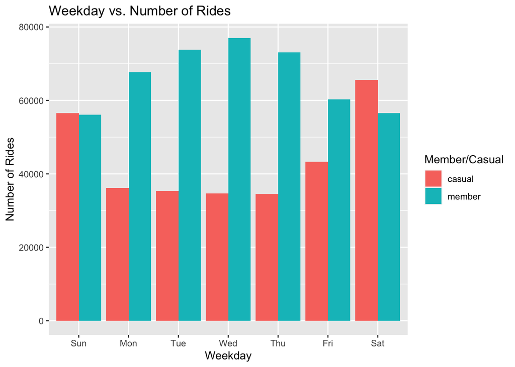

```r
all_2021_v2 %>%
  mutate(weekday = wday(started_at, label = TRUE)) %>%
  group_by(member_casual, weekday) %>%
  summarise(number_of_rides = n()
            ,average_duration = mean(ride_length)) %>%
  arrange(member_casual, weekday) %>%
  ggplot(aes(x = weekday, y = number_of_rides, fill = member_casual)) +
  geom_col(position = "dodge")+
  labs(x = "Weekday", y = "Number of Rides", title = "Weekday vs. Number of Rides", fill = "Member/Casual")
```

## Visualizing Rides by Average Duration

Notes: Here we used the same code as above and this time replaced number of rides to average duration, thus plotting weekday against average duration.

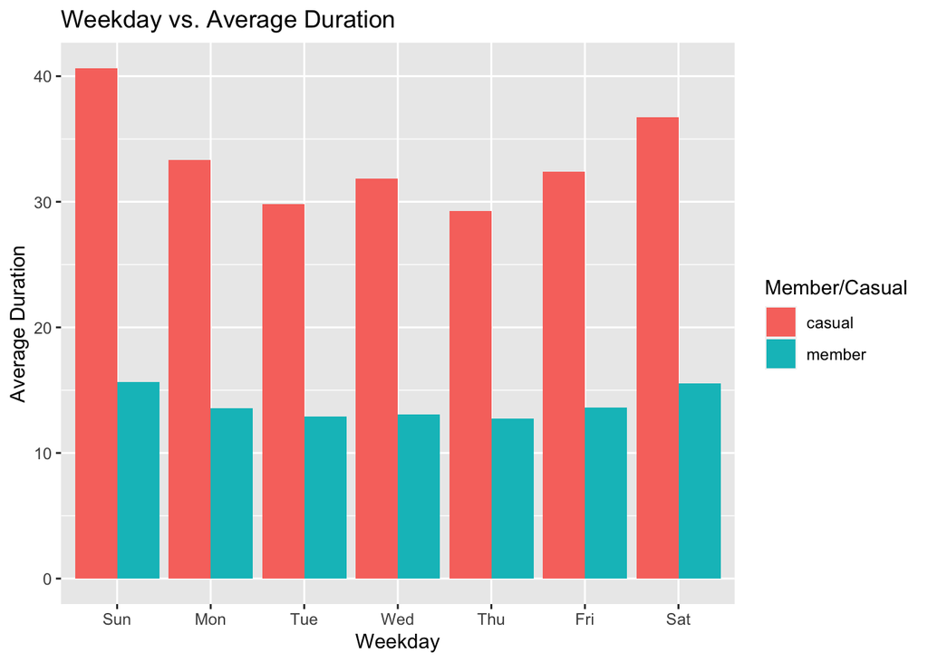

```r
all_2021_v2 %>%
  mutate(weekday = wday(started_at, label = TRUE)) %>%
  group_by(member_casual, weekday) %>%
  summarise(number_of_rides = n()
            ,average_duration = mean(ride_length)) %>%
  arrange(member_casual, weekday)  %>%
  ggplot(aes(x = weekday, y = average_duration, fill = member_casual)) +
  geom_col(position = "dodge")+
  labs(x = "Weekday", y = "Average Duration", title = "Weekday vs. Average Duration", fill = "Member/Casual")
```

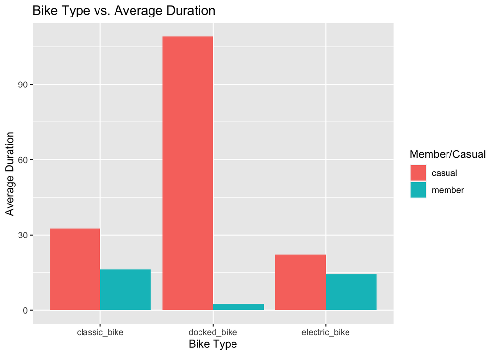

```r
all_2021_v2 %>%
  mutate(weekday = wday(started_at, label = TRUE)) %>%
  group_by(member_casual, weekday, rideable_type) %>%
  summarise(number_of_rides = n()
            ,average_duration = mean(ride_length)) %>%
  arrange(member_casual, weekday)  %>%
  ggplot(aes(x = rideable_type, y = average_duration, fill = member_casual)) +
  geom_col(position = "dodge")+
  labs(x = "Bike Type", y = "Average Duration", title = "Bike Type vs. Average Duration", fill = "Member/Casual")
```

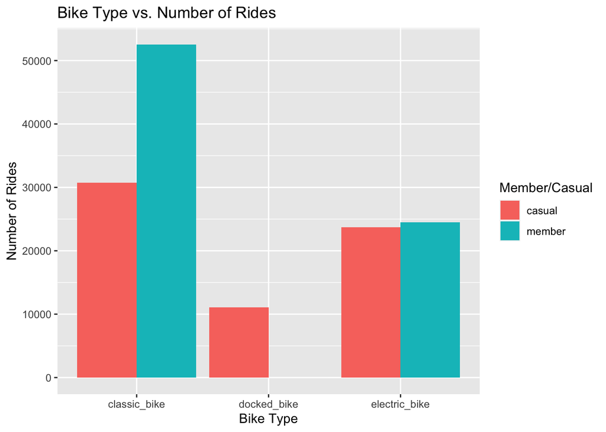

```r
all_2021_v2 %>%
  mutate(weekday = wday(started_at, label = TRUE)) %>%  #creates weekday field using wday()
  group_by(member_casual, weekday, rideable_type) %>%  #groups by usertype and weekday
  summarise(number_of_rides = n()                           #calculates the number of rides and average duration
            ,average_duration = mean(ride_length)) %>%      # calculates the average duration
  arrange(member_casual, weekday) %>%
  ggplot(aes(x = rideable_type, y = number_of_rides, fill = member_casual)) +
  geom_col(position = "dodge")+
  labs(x = "Bike Type", y = "Number of Rides", title = "Bike Type vs. Number of Rides", fill = "Member/Casual")
```